# Hoe zwaar weegt welvaart

Tutorial 1 Group 8

2026-06-17

# Set-up your environment

Title: “Hoe zwaar weegt welvaart” author: “‘Tobias Pierik: 2898032, Meike Bliek: 2892575, Vycho de Graaf: 2892702, Nynke Latham: 2862763, Anne Mak: 2898488’”

Tutorial lecturer’s name: Chantal Schouwenaar

In this document, we will examine income and the percentage of overweight people across Europe. We are curious to see if a correlation can be found between a country’s income and the percentage of overweight people. We started by adding two datasets, then cleaned and merged them into a single combined set. Following this, we created four graphs showing both the correlation between the two variables and the distribution of income and the percentage of overweight people across Europe.

# Part 1 - Identify a Social Problem

## 1.1 Describe the Social Problem

Social question: To what extent does income influence the percentage of overweight people in Europe?

# Part 1 - Identify a Social Problem

## 1.1 Describe the Social Problem

Social question: To what extent does income influence the percentage of overweight people in Europe?

This is a relevant topic because being overweight causes health problems (Zorginstituut Nederland, n.d.). By researching the correlation between wealth and being overweight, we can better understand how income determines health in a country. This gives us a clearer overview of whether there is a clear monetary cause in the national percentage of people who are overweight. We assume in advance that a high income enables men to eat more healthily and can thus largely prevent being overweight (De Witte, 2025).

# Part 2 - Data Sourcing

## 2.1 Load in the data

Eurostat. (n.d.). Obesity rate by body mass index (BMI) (sdg_02_10) [Data set]. Geraadpleegd op 2 juni 2026, van https://ec.europa.eu/eurostat/databrowser/view/sdg_02_10/default/table?lang=en

Eurostat. (2024, 7 november). Annual full-time adjusted salary in EU grew in 2023. European Commission. https://ec.europa.eu/eurostat/en/web/products-eurostat-news/w/DDN-20241107-1

# Part 3 - Quantifying

## 3.1 Data cleaning

In order to create our four graphs, we first had to clean our data. Both data sets contained many columns with no data, which we removed. The remaining columns were titled by numbers, so we renamed them with appropriate titles. The data sets also included a lot of general information about Europe as a whole, which was not relevant for our graphs and was therefore removed. Additionally, we excluded two countries with a large amount of missing data. Finally, we combined the two data sets by region. Later, when generating new variables, we assigned NA to the entries with missing data.

## 3.2 Generate necessary variables

Variable 1: For the first variable the average net yearly income per person for all the countries concluded in the dataset, was calculated. In the dataset we had the years 2002, 2006, 2010, 2014, 2018, 2022 included. After the calculations, there was an overview of the average net income per year. With these averages, the growth per was calculated. These calculations were later used in the temporal variation.

| INCgem2002 | INCgem2006 | INCgem2010 | INCgem2014 | INCgem2018 | INCgem2022 |
| --- | --- | --- | --- | --- | --- |
| 14327.42 | 23823.25 | 27478.03 | 29370.17 | 31593.03 | 36754.5 |

| groei_2002_2006 | groei_2006_2010 | groei_2010_2014 | groei_2014_2018 | groei_2018_2022 |
| --- | --- | --- | --- | --- |
| 66.27736 | 15.34124 | 6.886012 | 7.568419 | 16.33737 |

Variable 2: For the second variable, the same steps were done as in variable 1, but now the data from overweight was used. So first the average overweight percentage for all the countries was calculated for the years 2017, 2022, 2025. And then the average per year was used to calculate the growth. These calculations were also used later in the temporal variation graphic.

| OVgem2017 | OVgem2022 | OVgem2025 |
| --- | --- | --- |
| 53.41562 | 53.90882 | 54.54 |

| groei_2017_2022 | groei_2022_2025 |
| --- | --- |
| 0.9233226 | 1.170822 |

## 3.3 Visualize temporal variation

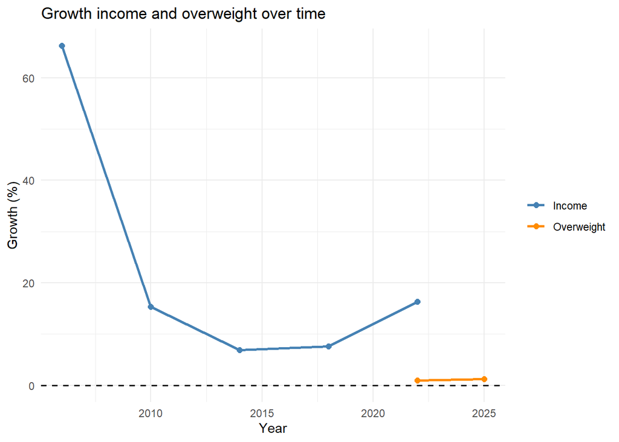

The graphic of temporal variation contains the growth difference from the yearly net income average, and the yearly overweight percentage average. The graphic has years on the X-axis and the growth in percentage on the Y-axis. The blue line shows the income growth percentage and the orange line shows the overweight growth percentage. The graphic shows a huge growth between 2002 and 2006. After 2006 there is a huge drop til 2014 in the growth percentage. After 2014 there is a steady incline. The growth percentage never became lower than zero. When you look at the graphic of the overweight growth percentage you see that there is not much information available. Therefore there is only a small incline visible in the graphic.

## 3.4 Visualize spatial variation

[output not shown]

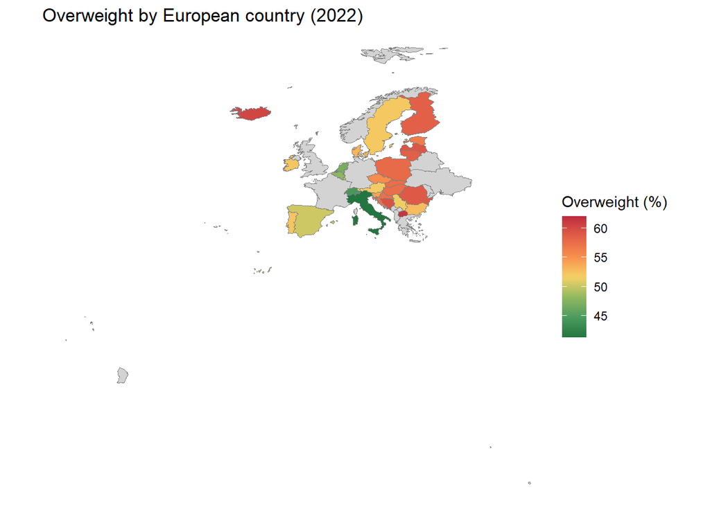

To visualize the spatial variation of the percentage of overweight people in various European countries, we decided to merge the data of the overweight percentages and the data of the income in European countries. We eventually made the decision to only use the overweight percentages, while using the combined data. A table containing the ISO codes of the countries was then added to make sure that the statistical data could be linked to the geographical data.

Using the “sf” and the “rnaturalearth” packages, a map of Europe was created. This map uses polygons, these are geographic boundaries of European countries. Russia was filtered to exclude it from the data, while we wanted to focus on the remaining European countries. The overweight data were then joined to the map data using the ISO codes.

Next, the variable “overweight2022” was combined into a numeric format so that it could be used for visualization. The missing values “:” were then treated as NA to make sure that countries with unavailable data were displayed on the map. We created a choropleth map with the “ggplot2” package. In this map, each country is colored according to its percentage of overweight individuals in 2022. We used the “paletteer” package to make the countries go from a green to red color palette. Countries that do not have data, are labeled with NA and these are shown with a light grey color.

# 3.5 Visualize sub-population variation

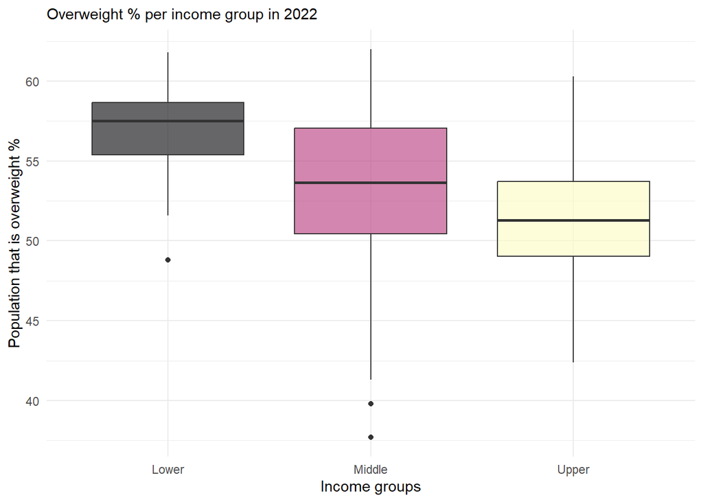

For the graph, we divided the 2022 income data into three subgroups: lower, middle, and upper income. We then compared these income groups with the percentage of overweight in each group. The black dots on the graph indicate the outliers in the dataset.

## 3.6 Event analysis

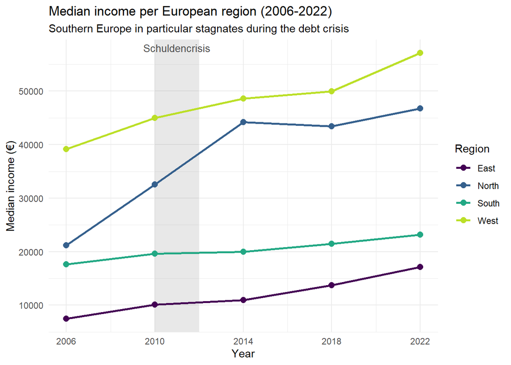

# Part 4 - Discussion

## 4.1 Discuss your findings

This report studied the relationship between income and the percentage of overweight people in European countries. Using data from Eurostat, we analyzed the data over time and across Europe. The observations of our data showed us clear differences between European countries. This confirms the widely held observation that poor economic conditions are associated with a greater risk of overweight. A possible explanation might be that people with lower incomes often have less access to healthy food, sports facilities, and other resources that support a healthy lifestyle.

In short, the findings suggest that lower income is related with larger levels of overweight in Europe, making economic inequality an crucial factor in acknowledging this public health issue.

# Part 5 - Reproducibility

## 5.1 Github repository link

https://github.com/meikebliek-gif/groep-8-werkgroup-1-programming-2

## 5.2 Reference list

Use APA referencing throughout your document. 1. Zorginstituut Nederland. (z.d.). Obesitaszorg en zorg bij overgewicht. Geraadpleegd op 16 juni 2026, van Zorginstituut Nederland 2. De Witte, E. (2025, 4 september). Geld maakt niet gelukkig, maar wel gezonder volgens nieuw onderzoek. Manly. https://manly.nl/verband-inkomen-gezondheid-onderzoek 3. Eurostat. (z.d.). Health determinants (hlth_det): Reference metadata in Euro SDMX Metadata Structure (ESMS). Geraadpleegd op 16 juni 2026, van https://ec.europa.eu/eurostat/cache/metadata/en/hlth_det_esms.htm 4. Eurostat. (2024, 7 november). Annual full-time adjusted salary in EU grew in 2023. Europese Commissie. https://ec.europa.eu/eurostat/en/web/products-eurostat-news/w/ddn-20241107-1 5. OpenAI. (2026). ChatGPT (GPT-5.5) [Large language model]. https://chatgpt.com/